# Analyze A/B Test Results

## Introduction

A/B tests are very commonly performed by data analysts and data scientists. For this project, you will be working to understand the results of an A/B test run by an e-commerce website. Your goal is to work through this notebook to help the company understand if they should:

- Implement the new webpage,
- Keep the old webpage, or
- Perhaps run the experiment longer to make their decision.

## Part I - Probability

```python
import pandas as pd
import numpy as np
import random
import matplotlib.pyplot as plt
%matplotlib inline
random.seed(42)
```

Below is the description of the data, there are a total of 5 columns:

|Data columns|Purpose|Valid values| | ------------- |:-------------| -----:| |user_id|Unique ID|Int64 values| |timestamp|Time stamp when the user visited the webpage|-| |group|In the current A/B experiment, the users are categorized into two broad groups.  
The `control` group users are expected to be served with `old_page`; and `treatment` group users are matched with the `new_page`.  
However, **some inaccurate rows** are present in the initial data, such as a `control` group user is matched with a `new_page`. |`['control', 'treatment']`| |landing_page|It denotes whether the user visited the old or new webpage.|`['old_page', 'new_page']`| |converted|It denotes whether the user decided to pay for the company's product. Here, `1` means yes, the user bought the product.|`[0, 1]`|

```python
df= pd.read_csv('ab_data.csv')
df.head()
```

|  | user_id | timestamp | group | landing_page | converted |
| --- | --- | --- | --- | --- | --- |
| 0 | 851104 | 2017-01-21 22:11:48.556739 | control | old_page | 0 |
| 1 | 804228 | 2017-01-12 08:01:45.159739 | control | old_page | 0 |
| 2 | 661590 | 2017-01-11 16:55:06.154213 | treatment | new_page | 0 |
| 3 | 853541 | 2017-01-08 18:28:03.143765 | treatment | new_page | 0 |
| 4 | 864975 | 2017-01-21 01:52:26.210827 | control | old_page | 1 |

```python
df.shape[0]
```

```
294478
```

The number of unique users in the dataset.

```python
tot = df.user_id.nunique()
tot
```

```
290584
```

The proportion of users converted.

```python
prop = df['converted'].sum()/tot
prop
```

```
0.12126269856564711
```

The number of times when the "group" is `treatment` but "landing_page" is not a `new_page`.

```python
df.query('group == "treatment" and landing_page !="new_page"',inplace=False).shape[0]
```

```
1965
```

```python
df.isnull().sum()
```

```
user_id         0
timestamp       0
group           0
landing_page    0
converted       0
dtype: int64
```

In a particular row, the **group** and **landing_page** columns should have either of the following acceptable values:

| user_id | timestamp | group | landing_page | converted |
| --- | --- | --- | --- | --- |
| XXXX | XXXX | `control` | `old_page` | X |
| XXXX | XXXX | `treatment` | `new_page` | X |

It means, the `control` group users should match with `old_page`; and `treatment` group users should matched with the `new_page`.

However, for the rows where `treatment` does not match with `new_page` or `control` does not match with `old_page`, we cannot be sure if such rows truly received the new or old wepage.

```python
df2=pd.concat([df.query("group == 'treatment' and landing_page== 'new_page'"),df.query("group == 'control' and landing_page== 'old_page'")])
df2.sample(10)
```

|  | user_id | timestamp | group | landing_page | converted |
| --- | --- | --- | --- | --- | --- |
| 29358 | 880498 | 2017-01-19 06:43:46.254639 | treatment | new_page | 0 |
| 211033 | 763799 | 2017-01-19 13:09:19.857931 | treatment | new_page | 0 |
| 169407 | 632343 | 2017-01-24 08:37:22.161110 | treatment | new_page | 0 |
| 32665 | 903948 | 2017-01-13 15:38:29.957051 | treatment | new_page | 0 |
| 142391 | 769981 | 2017-01-07 02:34:54.009149 | control | old_page | 0 |
| 58081 | 657961 | 2017-01-13 05:27:53.222276 | treatment | new_page | 0 |
| 162905 | 683764 | 2017-01-03 07:43:18.607799 | control | old_page | 0 |
| 210274 | 885435 | 2017-01-12 11:10:26.689049 | treatment | new_page | 0 |
| 166981 | 907762 | 2017-01-09 03:29:55.095954 | control | old_page | 0 |
| 238769 | 923758 | 2017-01-03 22:05:16.403630 | treatment | new_page | 0 |

```python
df2[((df2['group'] == 'treatment') == (df2['landing_page'] == 'new_page')) == False].shape[0]
```

```
0
```

Unique **user_id**s

```python
df2.user_id.nunique()
```

```
290584
```

Duplicates

```python
df2[df2.duplicated('user_id', keep = False)]
```

|  | user_id | timestamp | group | landing_page | converted |
| --- | --- | --- | --- | --- | --- |
| 1899 | 773192 | 2017-01-09 05:37:58.781806 | treatment | new_page | 0 |
| 2893 | 773192 | 2017-01-14 02:55:59.590927 | treatment | new_page | 0 |

```python
df2[df2.duplicated('user_id', keep = False)]['user_id'][1899]
```

```
773192
```

```python
df2.drop_duplicates(subset='user_id', inplace= True)
# Check again if the row with a duplicate user_id is deleted or not
df2[df2.duplicated('user_id', keep = False)]
```

|  | user_id | timestamp | group | landing_page | converted |
| --- | --- | --- | --- | --- | --- |

Probability of an individual converting regardless of the page they receive

```python
df['converted'].mean()
```

```
0.11965919355605512
```

Probabitlity that an individual in the `control` group converted.

```python
df.query("group=='control'")['converted'].mean()
```

```
0.12039917935897611
```

Probability that an individual in the `treatment` group converted

```python
df.query("group=='treatment'")['converted'].mean()
```

```
0.11891957956489856
```

```python
# The actual difference (obs_diff) between the conversion rates for the two groups.
df.query("group=='control'")['converted'].mean()-df.query("group=='treatment'")['converted'].mean()
```

```
0.0014795997940775518
```

The probability that an individual received the new page

```python
df['landing_page'].value_counts()[0]/df['landing_page'].value_counts().sum()
```

```
0.5
```

Mean value of converstion rate for control is more than treamtment group. Hence, treatment group should not lead to more converstions. The difference is small so we cannot say it for sure yet. This difference can appear by chance. So we can not say for sure using above results.

## Part II - A/B Test

Since a timestamp is associated with each event, we could run a hypothesis test continuously as long as you observe the events.

However, then the hard questions would be:

- Do you stop as soon as one page is considered significantly better than another or does it need to happen consistently for a certain amount of time?
- How long do you run to render a decision that neither page is better than another?

These questions are the difficult parts associated with A/B tests in general.

We assume that the old page is better unless the new page proves to be definitely better at a Type I error rate of 5%. The null and alternative hypotheses are **$H_0$** and **$H_1$** respectively.

$$ H_0: p_{old} >= p_{new}\\ H_1: p_{old} < p_{new} $$

### ToDo 2.2 - Null Hypothesis $H_0$ Testing

Under the null hypothesis $H_0$, we assume that $p_{new}$ and $p_{old}$ are equal. Furthermore, we assume that $p_{new}$ and $p_{old}$ both are equal to the **converted** success rate in the `df2` data regardless of the page. So, our assumption is:

$p_{new}$ = $p_{old}$ = $p_{population}$

The **conversion rate** for $p_{new}$ under the null hypothesis.

```python
p_new = df2.converted.mean()
p_new
```

```
0.11959708724499628
```

The **conversion rate** for $p_{old}$ under the null hypothesis.

```python
p_old= df2.converted.mean()
p_old
```

```
0.11959708724499628
```

Number of individuals in the treatment group:

```python
n_new = df2.query("landing_page=='new_page'").user_id.nunique()
n_new
```

```
145310
```

Number of individuals in the control group.

```python
n_old = df2.query("landing_page=='old_page'").user_id.nunique()
n_old
```

```
145274
```

We simulate $n_{new}$ transactions with a conversion rate of $p_{new}$ under the null hypothesis.

```python
new_page_converted= np.random.choice([0,1],size=n_new,p=[p_new,1-p_new])
```

We simulate $n_{old}$ transactions with a conversion rate of $p_{old}$ under the null hypothesis.

```python
old_page_converted= np.random.choice([0,1],size=n_old,p=[p_old,1-p_old])
```

```python
obs_diff = df2['converted'][df2['group'] == 'treatment'].mean() - df2['converted'][df2['group'] == 'control'].mean()
obs_diff
```

```
-0.0015782389853555567
```

**Sampling distribution**  
Now, we re-create `new_page_converted` and `old_page_converted` and find the $(p{'}_{new}$ - $p{'}_{old})$ value 10,000 times using the same simulation process as above.

```python
new_page_converted= np.random.binomial(n_new, p_new, 10000)/n_new
old_page_converted= np.random.binomial(n_old, p_old, 10000)/n_old
p_diffs=new_page_converted-old_page_converted
```

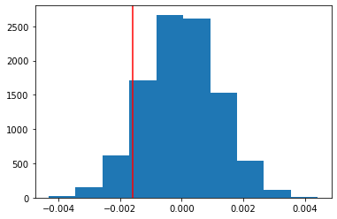

```python
plt.hist(p_diffs)
plt.axvline(obs_diff, c='r')
```

```python
(p_diffs >obs_diff).mean()
```

```
0.9029
```

This value is called p-value. This value needs to be less than Type I error rate for us to reject the null hypothesis. Otherwise, we fail to reject null hypothesis.

```python
import statsmodels.api as sm

# number of conversions with the old_page
convert_old = df2.query("landing_page=='old_page'").converted.sum()

# number of conversions with the new_page
convert_new = df2.query("landing_page=='new_page'").converted.sum()

# number of individuals who were shown the old_page
n_old = df2.query("landing_page=='old_page'").shape[0]

# number of individuals who received new_page
n_new = df2.query("landing_page=='new_page'").shape[0]
```

```python
import statsmodels.api as sm
# ToDo: Complete the sm.stats.proportions_ztest() method arguments
z_score, p_value = sm.stats.proportions_ztest([convert_old,convert_new],[n_old,n_new],alternative='smaller')
print(z_score, p_value)
```

```
1.3109241984234394 0.9050583127590245
```

$z_{alpha} = 1.625$ As z*score < $z*{alpha}$, we fail to reject to null hypothesis which is same as our previous result in j.

### Part III - A regression approach

In this case, we need to use logistic regression.

```python
df2['intercept']=1
df2['ab_page']=pd.get_dummies(df2['group'])['treatment']
df2.head()
```

|  | user_id | timestamp | group | landing_page | converted | intercept | ab_page |
| --- | --- | --- | --- | --- | --- | --- | --- |
| 2 | 661590 | 2017-01-11 16:55:06.154213 | treatment | new_page | 0 | 1 | 1 |
| 3 | 853541 | 2017-01-08 18:28:03.143765 | treatment | new_page | 0 | 1 | 1 |
| 6 | 679687 | 2017-01-19 03:26:46.940749 | treatment | new_page | 1 | 1 | 1 |
| 8 | 817355 | 2017-01-04 17:58:08.979471 | treatment | new_page | 1 | 1 | 1 |
| 9 | 839785 | 2017-01-15 18:11:06.610965 | treatment | new_page | 1 | 1 | 1 |

```python
df2.sample(10)
```

|  | user_id | timestamp | group | landing_page | converted | intercept | ab_page |
| --- | --- | --- | --- | --- | --- | --- | --- |
| 94948 | 642662 | 2017-01-17 05:53:57.112871 | control | old_page | 1 | 1 | 0 |
| 288071 | 927457 | 2017-01-09 01:06:04.509472 | control | old_page | 0 | 1 | 0 |
| 18621 | 783287 | 2017-01-04 11:06:31.122089 | control | old_page | 0 | 1 | 0 |
| 9359 | 860106 | 2017-01-11 09:02:46.191445 | treatment | new_page | 0 | 1 | 1 |
| 46378 | 919386 | 2017-01-17 18:46:09.672617 | treatment | new_page | 0 | 1 | 1 |
| 2426 | 929406 | 2017-01-09 07:55:51.909481 | control | old_page | 0 | 1 | 0 |
| 84958 | 938193 | 2017-01-05 18:52:36.394110 | control | old_page | 0 | 1 | 0 |
| 209323 | 651394 | 2017-01-15 17:21:38.957549 | control | old_page | 0 | 1 | 0 |
| 86236 | 807459 | 2017-01-04 19:17:59.220923 | control | old_page | 0 | 1 | 0 |
| 112806 | 883539 | 2017-01-09 12:10:44.436367 | control | old_page | 1 | 1 | 0 |

```python
logistic_regression = sm.Logit(df2['converted'],df2[['intercept','ab_page']])
res = logistic_regression.fit()
```

```
Optimization terminated successfully.
         Current function value: 0.366118
         Iterations 6
```

```python
res.summary2()
```

| Model: | Logit | Pseudo R-squared: | 0.000 |
| --- | --- | --- | --- |
| Dependent Variable: | converted | AIC: | 212780.3502 |
| Date: | 2022-07-20 19:38 | BIC: | 212801.5095 |
| No. Observations: | 290584 | Log-Likelihood: | -1.0639e+05 |
| Df Model: | 1 | LL-Null: | -1.0639e+05 |
| Df Residuals: | 290582 | LLR p-value: | 0.18988 |
| Converged: | 1.0000 | Scale: | 1.0000 |
| No. Iterations: | 6.0000 |  |  |

|  | Coef. | Std.Err. | z | P>\|z\| | [0.025 | 0.975] |
| --- | --- | --- | --- | --- | --- | --- |
| intercept | -1.9888 | 0.0081 | -246.6690 | 0.0000 | -2.0046 | -1.9730 |
| ab_page | -0.0150 | 0.0114 | -1.3109 | 0.1899 | -0.0374 | 0.0074 |

There can be many factors influencing converstaion rate. It is good idea to add them to regression model because they may have huge influence on results which might get neglected otherwise. The disadvantage is that it can affect result in any direction.

```python
# Read the countries.csv
countries=pd.read_csv('countries.csv')
```

```python
# Join with the df2 dataframe
df_merged = countries.set_index('user_id').join(df2.set_index('user_id'), how='inner')
df_merged.head()
```

| user_id | country | timestamp | group | landing_page | converted | intercept | ab_page |
| --- | --- | --- | --- | --- | --- | --- | --- |
| 834778 | UK | 2017-01-14 23:08:43.304998 | control | old_page | 0 | 1 | 0 |
| 928468 | US | 2017-01-23 14:44:16.387854 | treatment | new_page | 0 | 1 | 1 |
| 822059 | UK | 2017-01-16 14:04:14.719771 | treatment | new_page | 1 | 1 | 1 |
| 711597 | UK | 2017-01-22 03:14:24.763511 | control | old_page | 0 | 1 | 0 |
| 710616 | UK | 2017-01-16 13:14:44.000513 | treatment | new_page | 0 | 1 | 1 |

```python
# Create the necessary dummy variables
df_merged[['US','UK']]=pd.get_dummies(df_merged['country'])[['US','UK']]
df_merged['US_ab_page']=df_merged['US']*df_merged['ab_page']
df_merged['UK_ab_page']=df_merged['UK']*df_merged['ab_page']
df_merged.head()
```

| user_id | country | timestamp | group | landing_page | converted | intercept | ab_page | US | UK | US_ab_page | UK_ab_page |
| --- | --- | --- | --- | --- | --- | --- | --- | --- | --- | --- | --- |
| 834778 | UK | 2017-01-14 23:08:43.304998 | control | old_page | 0 | 1 | 0 | 0 | 1 | 0 | 0 |
| 928468 | US | 2017-01-23 14:44:16.387854 | treatment | new_page | 0 | 1 | 1 | 1 | 0 | 1 | 0 |
| 822059 | UK | 2017-01-16 14:04:14.719771 | treatment | new_page | 1 | 1 | 1 | 0 | 1 | 0 | 1 |
| 711597 | UK | 2017-01-22 03:14:24.763511 | control | old_page | 0 | 1 | 0 | 0 | 1 | 0 | 0 |
| 710616 | UK | 2017-01-16 13:14:44.000513 | treatment | new_page | 0 | 1 | 1 | 0 | 1 | 0 | 1 |

```python
# Fit your model, and summarize the results
model = sm.Logit(df_merged['converted'],df_merged[['intercept','ab_page','US','UK','US_ab_page','UK_ab_page']])
res2=model.fit()
res2.summary2()
```

```
Optimization terminated successfully.
         Current function value: 0.366109
         Iterations 6
```

| Model: | Logit | Pseudo R-squared: | 0.000 |
| --- | --- | --- | --- |
| Dependent Variable: | converted | AIC: | 212782.6602 |
| Date: | 2022-07-20 19:38 | BIC: | 212846.1381 |
| No. Observations: | 290584 | Log-Likelihood: | -1.0639e+05 |
| Df Model: | 5 | LL-Null: | -1.0639e+05 |
| Df Residuals: | 290578 | LLR p-value: | 0.19199 |
| Converged: | 1.0000 | Scale: | 1.0000 |
| No. Iterations: | 6.0000 |  |  |

|  | Coef. | Std.Err. | z | P>\|z\| | [0.025 | 0.975] |
| --- | --- | --- | --- | --- | --- | --- |
| intercept | -2.0040 | 0.0364 | -55.0077 | 0.0000 | -2.0754 | -1.9326 |
| ab_page | -0.0674 | 0.0520 | -1.2967 | 0.1947 | -0.1694 | 0.0345 |
| US | 0.0175 | 0.0377 | 0.4652 | 0.6418 | -0.0563 | 0.0914 |
| UK | 0.0118 | 0.0398 | 0.2957 | 0.7674 | -0.0663 | 0.0899 |
| US_ab_page | 0.0469 | 0.0538 | 0.8718 | 0.3833 | -0.0585 | 0.1523 |
| UK_ab_page | 0.0783 | 0.0568 | 1.3783 | 0.1681 | -0.0330 | 0.1896 |

All of the p-values are still greater than Type I error rate for every category. Hence, we still fail to reject null hypothesis for all countries.